# Carga de datos y programación básica en R

## Control flow

El *control flow* es un conjunto de funciones que permiten manejar las órdenes de manera estructurada y lógica. Las más importantes son:

- if
- if - else
- for
- while
- repeat
- break
- next

```r
?Control
```

### Loops

Todos los lenguajes modernos de programación ofrecen una o más maneras de realizar operaciones iterativas. El poder repetir la misma acción una cantidad indefinida de veces es una de las grandes ventajas de realizar las tareas mediante programación.

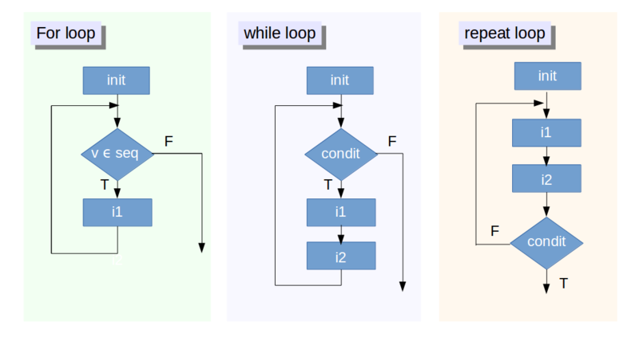

**for**

Sirve para crear tareas repetitivas de un número de pasos específico.

Uno de los usos más frecuentes de un ciclo for es la configuración de métodos de remuestreo (bootstraping).

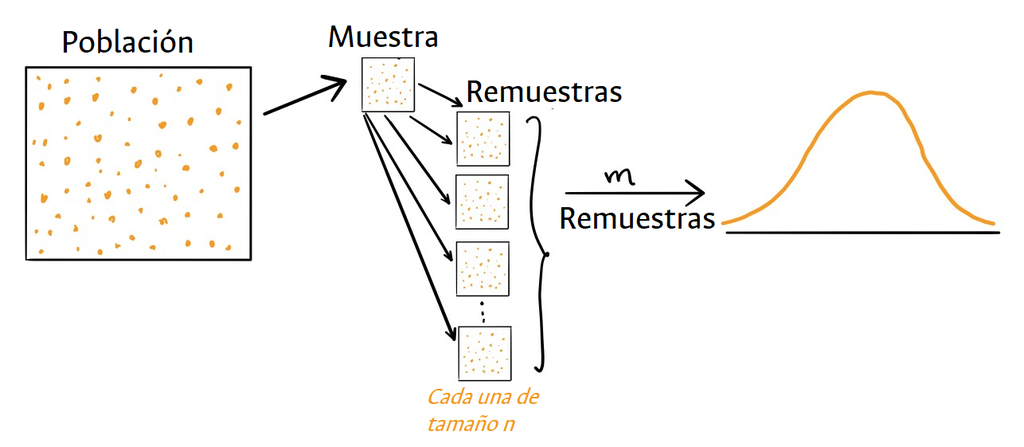

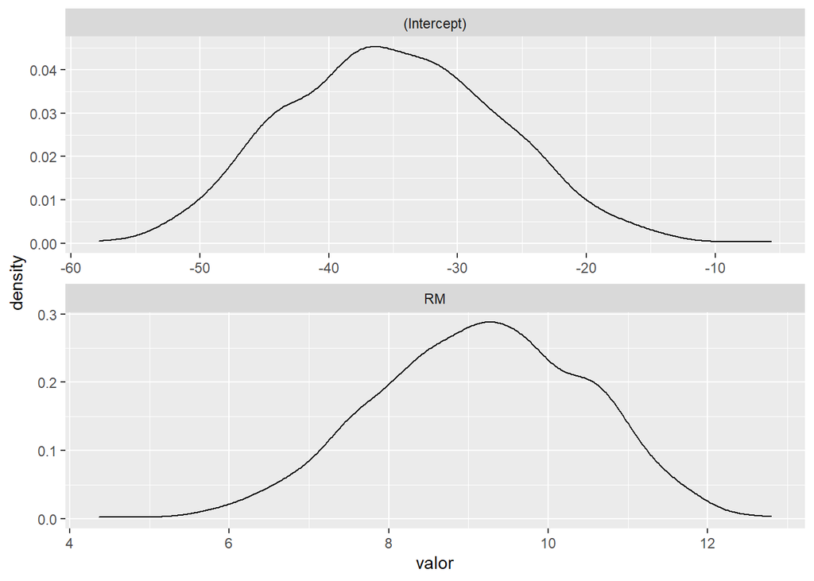

```r
#vamos a guardar en una lista los coeficientes de una regresión
coeficientes <- list()

# inicializo el ciclo for
for(i in 1:1000){
  #en cada paso

  # 1. saco una muestra de 100 casas
  muestra <- sample_n(boston_housing_xlsx, 100)

  # 2. ajusto un modelo de regresión lineal
  lm(MEDV ~ RM, data = muestra) -> modelo

  # 3. extraigo y almaceno los coeficientes del modelo
  coeficientes[[i]] <- coefficients(modelo)
}

# grafico el comportamiento de los coeficientes
coeficientes %>%
  transpose %>%
  lapply(unlist) %>%
  as_tibble() %>%
  gather(key = coeficiente, value = valor) %>%
  ggplot +
  aes(x = valor) +
  geom_density() +
  facet_wrap(~coeficiente, nrow = 2,  scales = "free")
```

**while**

Sirve para crear tareas repetitivas que no sabemos después de cuántos pasos terminan. Requiere una inicialización cuidadosa.

**Ejemplo**: [¿Cuántos sobres tengo que comprar para llenar un álbum de 100 cromos?](https://www.lanacion.com.ar/economia/peleados-con-los-algoritmos-los-economistas-y-su-talon-de-aquiles-nid2076973/)

```r
# inicializo las condiciones de partida
album <- iteracion <- 0
# creo la condición lógica que permite ejecutar el proceso
aun_falta <- TRUE

# siempre que aun_falta siga siendo verdadero
while(aun_falta){
  # en cada ciclo

  # 1. actualizo en qué iteración voy
  iteracion <- iteracion + 1

  # 2. extraigo una muestra de 6 números ("compro un sobre con 6 cromos")
  sobre <- sample(100, 6)

  # 3.1 tomo el álbum
  # 3.2 le combino los cromos que obtuve
  # 3.3 ordeno los cromos de menor a mayor
  # 3.4 dejo valores únicos (quito cromos duplicados)
  # 3.5 actualizo el álbum
  album %>% c(sobre) %>% sort %>% unique -> album

  # 4. si tengo menos de 100 cromos es porque me falta
  length(album) < 100 -> aun_falta
}

# muestro el número de iteraciones
# es decir, cuántos sobres tuve que comprar
iteracion
```

```
## [1] 61
```

## if, else

La estructura if sirve para ejecutar varias rutinas distintas dependiendo de una condición lógica. En caso de que sea necesario, es posible aplicar una rutina alterna con la estructura else.

**Ejemplo**: Prueba de normalidad.

Diversas pruebas y modelos estadísticos requieren verificar el *supuesto* de **normalidad en los datos**.

[figure not shown]

```r
# de la base de datos de carros
# extraigo la variable mpg
# le hago un test de shapiro
# guardo los resultados de la prueba en un objeto llamado prueba_sw
mtcars[["mpg"]] %>% shapiro.test() -> prueba_sw

# estructura condicional
if(prueba_sw$p.value > 0.05){
  # Si acepto la hipótesis de normalidad en la variable mpg
  # Hago una prueba t
  print("La variable mpg sigue una distribución normal")
  print("Realizo una prueba t")
  t.test(mpg ~ vs, data = mtcars)
} else {
  # Si rechazo la hipótesis de normalidad en la variable mpg
  # Hago una prueba Mann-Whitney-Wilcoxon
  print("La variable mpg no sigue una distribución normal")
  print("Realizo una prueba Mann-Whitney-Wilcoxon")
  wilcox.test(mpg ~ vs, data = mtcars)
}
```

```
## [1] "La variable mpg sigue una distribución normal"
## [1] "Realizo una prueba t"
```

```
##
##  Welch Two Sample t-test
##
## data:  mpg by vs
## t = -4.6671, df = 22.716, p-value = 0.0001098
## alternative hypothesis: true difference in means between group 0 and group 1 is not equal to 0
## 95 percent confidence interval:
##  -11.462508  -4.418445
## sample estimates:
## mean in group 0 mean in group 1
##        16.61667        24.55714
```